# Intro to Parallel Computing in R

Malcolm Itter

10/25/2018

```r
# Load libraries
library(parallel)
library(snow)
setDefaultClusterOptions(type="SOCK")
library(snowfall)
library(tictoc)
library(rbenchmark)
library(coda)
```

```r
git clone https://github.com/REC-Helsinki/ParallelR-Workshop
```

After downloading the workshop directory, you can compile the .Rmd file to produce an .html or you may run the R code within the .Rmd file interactively with the workshop—this is my suggestion.

## Fundamentals

Let’s review some basic concepts that will be useful as we proceed to more complex parallel tasks. Specifically, we will look at “vectorized” versus non-vectorized operations, the family of `apply` functions, and how to benchmark tasks in R.

### For loops vs. vectorized operations

An operation is vectorized when it acts on an entire vector of values simultaneously, rather than each component in sequence. Let’s simulate flipping a coin a million times to demonstrate the difference in the amount of time it takes to complete the operation. We will use the `tictoc` functions to keep track of the time.

```r
#### Coin flip ####

# Number of flips
n = 1E06

# For loop - no preallocation of memory
tic("for_loop") # Sets the timer
set.seed(1) # sets the seed for the RNG (so results are consistent)
val1 = vector()
for (i in 1:n){
  val1[i] = ifelse(runif(1)>0.5,1,0)
}
toc() # Stops the timer
```

```
## for_loop: 4.74 sec elapsed
```

```r
# For loop - preallocate memory
tic("for_loop-preallocate")
set.seed(1)
val1 = rep(NA,n) # Here we preallocate memory for a vector of size n
for (i in 1:n){
  val1[i] = ifelse(runif(1)>0.5,1,0)
}
toc()
```

```
## for_loop-preallocate: 4.202 sec elapsed
```

```r
# Vectorized operation
tic("vectorized")
set.seed(1)
val2 = ifelse(runif(n)>0.5,1,0)
toc()
```

```
## vectorized: 0.206 sec elapsed
```

```r
all(val1==val2) # check the results (thanks set.seed)
```

```
## [1] TRUE
```

## `apply` functions

```r
#### Row means ####

## Form matrix
n = 1E05
p = 5
X = matrix(sample.int(100,n*p,replace=T),n,p)

# For loop
tic("for_loop")
d1 = rep(NA,n)
for (i in 1:n){
  d1[i] = mean(X[i,])
}
toc()
```

```
## for_loop: 0.408 sec elapsed
```

```r
# Apply
tic("apply")
d2 = apply(X,1,mean)
toc()
```

```
## apply: 0.511 sec elapsed
```

```r
# Rowmeans function (for loop in C)
tic("rowmeans")
d3 = rowMeans(X)
toc()
```

```
## rowmeans: 0.026 sec elapsed
```

```r
# Vectorized
tic("vectorized")
d4 = X%*%rep(1/p,p)
toc()
```

```
## vectorized: 0.007 sec elapsed
```

#### Use `benchmark` function

The `benchmark` function allows us to compare the amount of time it takes to complete a task using alternative approaches. The time it takes to complete a task in R can vary, so benchmark runs each process for a user-specified number of replicates and ranks the processes from longest to shortest. Let’s compare calculating row means using C versus a vectorized operation in R.

```r
#### rowMeans() vs. vectorized row means ####

n.reps = 1000
one = rep(1/p,p) # Let's make it a fair fight

benchmark("rowMeans"={d3=rowMeans(X)},
          "vectorized"={d4=X%*%one},
          replications=n.reps,
columns = c("test", "replications", "elapsed",
            "relative", "user.self", "sys.self"))
```

```
##         test replications elapsed relative user.self sys.self
## 1   rowMeans         1000   3.454    1.172     3.023    0.414
## 2 vectorized         1000   2.946    1.000     2.465    0.470
```

#### Data processing example

We can also use the `apply` family of functions to help us process our data efficiently. In the following example, `tapply` greatly improves the time it takes to process a numeric variable based on the values of an index stored as a categorical variable within a common data.frame.

```r
#### Process data using apply ####

# Load example data
tree.growth = read.csv("TreeWest.csv")
head(tree.growth)
```

```
##   Tree Stand Species     Host Year age    inc    dbh dbh.lag
## 1    1    06    Pima Non-Host 1985   1 0.3660 0.0732  0.0000
## 2    1    06    Pima Non-Host 1986   2 0.3975 0.1527  0.0732
## 3    1    06    Pima Non-Host 1987   3 0.3070 0.2141  0.1527
## 4    1    06    Pima Non-Host 1988   4 0.3330 0.2807  0.2141
## 5    1    06    Pima Non-Host 1989   5 0.4385 0.3684  0.2807
## 6    1    06    Pima Non-Host 1990   6 0.5740 0.4832  0.3684
```

```r
tic("for_loop")
tree.idx = unique(tree.growth$Tree)
age1 = rep(NA,nrow(tree.growth))
for (i in 1:length(tree.idx)){
  tree.rows = which(tree.growth$Tree==tree.idx[i])
  tree.yrs = tree.growth$Year[tree.rows]
  age1[tree.rows] = tree.yrs - min(tree.yrs) + 1
}
toc()
```

```
## for_loop: 0.247 sec elapsed
```

```r
tic("apply")
age2 = tree.growth$Year -
  rep(tapply(tree.growth$Year,tree.growth$Tree,min),
      tapply(tree.growth$Tree,tree.growth$Tree,length)) + 1
toc()
```

```
## apply: 0.01 sec elapsed
```

```r
all(age1==age2) # check results
```

```
## [1] TRUE
```

## Parallel `apply`

One reason the `apply` functions are nice is that in addition to allowing complex operations to be expressed succintly, many parallel versions of these functions exist. This will be the basis for the parallel operations we present later on. First, let’s see an example using a simple linear regression model. Specifically, let’s fit a regression model that estimates mean annual tree growth as a function of tree age for each tree in our tree growth dataset.
$$y_{i,t} = \beta_{i,0} + \beta_{i,1}\text{age}_{i,t} + \epsilon_{i,t}$$

```r
#### SLR example ####

tic("for_loop")
mod1 = list()
for (i in 1:length(tree.idx)){
  mod1[[i]] = lm(inc~age,data=tree.growth[tree.growth$Tree==tree.idx[i],])
}
toc()
```

```
## for_loop: 1.563 sec elapsed
```

```r
tic("lapply")
mod2 = lapply(tree.idx,function(x){
  lm(inc~age,data=tree.growth[tree.growth$Tree==x,])
})
toc()
```

```
## lapply: 1.428 sec elapsed
```

The for loop and the `lapply` calls take nearly the same time to run. This is not surprising as they are nearly identical and both rely on for loops written in R. But, we can parallelize the `lapply` call and fit the model using multiple cores. Here, we will use the `parLapply` function from the `snow` library.

```r
# Determine your number of cores
my.cores = detectCores() - 1

# Initialize a cluster
cl = makeCluster(my.cores)

# Move the tree growth dataset to each node
clusterExport(cl,"tree.growth")

# Run lapply in parallel
tic("parallel-apply")
mod3 = parLapply(cl,tree.idx,function(x){
  lm(inc~age,data=tree.growth[tree.growth$Tree==x,])
})
toc()
```

```
## parallel-apply: 0.885 sec elapsed
```

```r
stopCluster(cl)
```

## Applied analysis: Modeling willow tit occurrence

Let’s bring what we have learned so far together to conduct an applied analysis. We will model willow tit occupancy in the Swiss Alps using a dataset described in Royle and Dorazio (2008). We will use the willow tit data to demonstrate the model selection techniques presented in Hooten and Hobbs (2015a) utilizing parallel operations to speed up computationally intensive processes including bootstrapping, Markov chain Monte Carlo (MCMC), and cross-validation.

#### Willow tit data

Data citation: Hooten and Hobbs (2015b)

```r
wt = read.csv("http://esapubs.org/archive/mono/M085/001/wt.csv",header=T)
head(wt)
```

```
##   y.1 y.2 y.3 elev forest
## 1   0   0   0  420      3
## 2   0   0   0  450     21
## 3   0   0   0 1050     32
## 4   0   0   0 1110     35
## 5   0   0   0  510      2
## 6   0   0   0  630     60
```

We have observations of willow tit occurrence (0=absent, 1=present) from a set of $n$ sites. Each site was visited 1-3 times. Along with the occurrence data, we have observations of elevation and forest cover to use as covariates.

#### GLM

Let’s fit a naive GLM for starters,

$$\begin{align}
y_{i} &= \sum_{j=1}^{J_{i}}y_{ij}\\[4pt]
y_{i} &\sim \text{Binomial}(J_{i},\pi_{i})\\[4pt]
\text{logit}(\pi_{i}) &= \beta_{0} + \beta_{1}\text{elev}_{i}
\end{align}$$
where $i, i=1,\ldots,n$ indexes site, $j, j=1,\ldots,J_{i}$ indexes visit up to a total number of visits $J_{i}$, and $\pi_{i}$ is the probability of occurrence at site $i$.

```r
#### Willow tit: Naive GLM ####

n = 200
wt = wt[1:n,] # limit observations to the first 200 rows
resp = c("y.1","y.2","y.3") # define response columns
wt$visits = apply(wt[,resp],1,function(x)sum(!is.na(x))) # calculate the number of site visits
wt$detect = apply(wt[,resp],1,function(x)sum(x,na.rm=T)) # calculate the number of visits during which the willow tit was detected
wt$prop = wt$detect/wt$visits # calculate the proportion of visits during which the willow tit was detected
elev.std = scale(wt$elev); a.elev=attr(elev.std,"scaled:center"); b.elev=attr(elev.std,"scaled:scale")
wt$elev.std = as.numeric(elev.std) # center and scale the elevation variable

# Fit GLM model
mod = glm(prop~elev.std,data=wt,family=binomial,weights=visits)
summary(mod)
```

```
##
## Call:
## glm(formula = prop ~ elev.std, family = binomial, data = wt,
##     weights = visits)
##
## Deviance Residuals:
##     Min       1Q   Median       3Q      Max
## -3.5358  -0.8937  -0.6142   0.8032   4.0065
##
## Coefficients:
##             Estimate Std. Error z value Pr(>|z|)
## (Intercept)  -1.3605     0.1237  -11.00   <2e-16 ***
## elev.std      1.4274     0.1290   11.06   <2e-16 ***
## ---
## Signif. codes:  0 '***' 0.001 '**' 0.01 '*' 0.05 '.' 0.1 ' ' 1
##
## (Dispersion parameter for binomial family taken to be 1)
##
##     Null deviance: 558.34  on 199  degrees of freedom
## Residual deviance: 388.81  on 198  degrees of freedom
## AIC: 437.52
##
## Number of Fisher Scoring iterations: 4
```

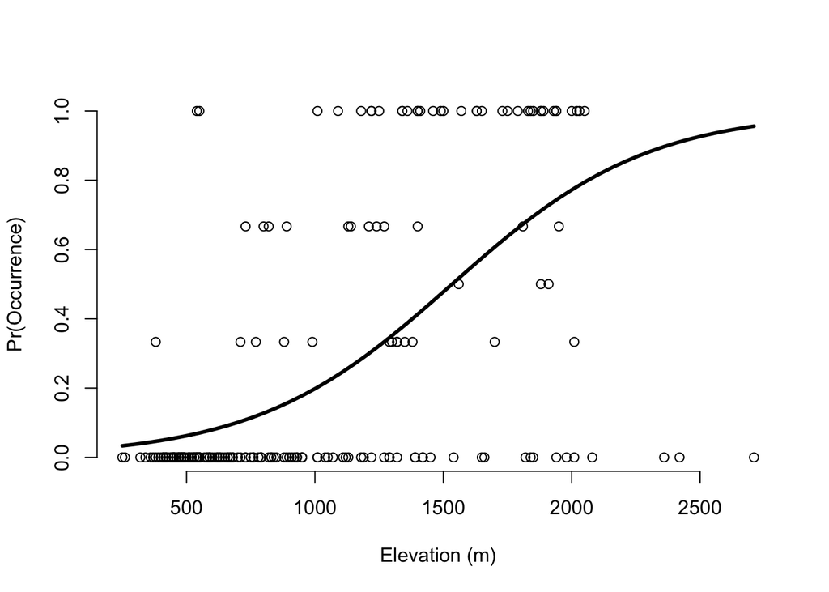

```r
# Plot fitted probability values as function of elevation
n.step = 50
elev.df = data.frame(elev.std=seq(min(wt$elev.std),max(wt$elev.std),length=n.step))
elev.df$elev = a.elev+b.elev*elev.df$elev.std
elev.df$pred.mean = predict(mod,newdata=elev.df,type="response")
plot(wt$elev,wt$prop,xlab="Elevation (m)",ylab="Pr(Occurrence)",axes=F); axis(1); axis(2)
lines(elev.df$elev,elev.df$pred.mean,lwd=3)
```

#### Parallel bootstrap

Confidence intervals for GLMs can be difficult to construct (although an analytical solution exists for binomial data with a logit link), so let’s use a non-parametric bootstrap to generate simulated confidence intervals for our estimated mean probabilities. We will compare the time it takes to run our bootstrap in sequence versus in parallel.

```r
#### Willow tit: Bootstrap confidence interval ####

# Let's not use predict function -- it's slow!
X = cbind(rep(1,n.step),elev.df$elev.std) # construct design matrix
inv.logit = function(x){
  1/(1+exp(-x))
} # inverse logit function to backtransform fitted values

# Set bootstrap parameters
n.sim = 10000
seed = 1
samps = matrix(sample(1:n,n*n.sim,replace=T),n.sim,n,byrow=T)

# For loop
tic("sequential-bootstrap")
set.seed(seed)
pred.vals = array(NA,dim=c(n.sim,n.step))
# bar = txtProgressBar(min=1,max=(n.sim+1),initial=0,style=3,char="*",width=50,title=m)
for (i in 1:n.sim){
  sim.coef = coefficients(glm(prop~elev.std,data=wt[samps[i,],],family=binomial,weights=visits))
  pred.vals[i,] = inv.logit(X%*%sim.coef)
  # setTxtProgressBar(bar,i)
}
elev.df[,c("lwr","upr")] = t(apply(pred.vals,2,function(x)quantile(x,c(0.025,0.975))))
toc()
```

```
## sequential-bootstrap: 21.381 sec elapsed
```

```r
# In parallel - use snow::clusterApplyLB
tic("parallel-bootstrap")
set.seed(seed)
# Define bootstrap function
boot.ci = function(i){
  sim.coef = coefficients(glm(prop~elev.std,data=wt[samps[i,],],family=binomial,weights=visits))
  return(as.numeric(inv.logit(X%*%sim.coef)))
}
cl = makeCluster(my.cores)
clusterExport(cl,list("X","wt","samps","inv.logit")) # pass necessary inputs to all nodes
par.pred.vals = do.call("rbind",clusterApplyLB(cl,1:n.sim,boot.ci)) # run parallel bootstrap
stopCluster(cl)
elev.df[,c("lwr2","upr2")] = t(apply(par.pred.vals,2,function(x)quantile(x,c(0.025,0.975))))
toc()
```

```
## parallel-bootstrap: 18.328 sec elapsed
```

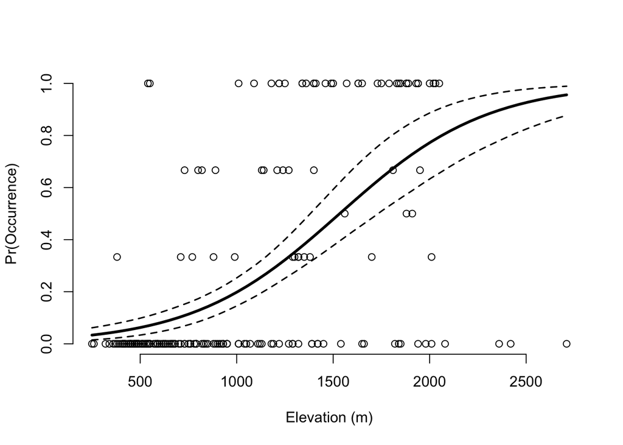

```r
# Add confidence interval to plot
plot(wt$elev,wt$prop,xlab="Elevation (m)",ylab="Pr(Occurrence)",axes=F); axis(1); axis(2)
lines(elev.df$elev,elev.df$pred.mean,lwd=3)
lines(elev.df$elev,elev.df$lwr2,lty="dashed",lwd=1.6)
lines(elev.df$elev,elev.df$upr2,lty="dashed",lwd=1.6)
```

#### Bayesian hierarchical model

In our naive GLM we confounded detection probability and the probability of occurrence. As described in Dorazio and Rodriguez (2012), our observations ($y_{i}$) are actually the product of the detection probability $p$ and a latent, Bernoulli random variable ($z_{i}$), indicating whether the willow tit is present or absent at site $i$,

$$\begin{align}
y_{i} &\sim \left\{\begin{array}{ll}
0 & \text{if}\;z_{i}=0\\
\text{Binomial}(J_{i},p) & \text{if}\;z_{i}=1
\end{array}\right.\\[8pt]
z_{i} &\sim \left\{\begin{array}{ll}
0 & \text{if}\; v_{i} \leq 0\\
1 & \text{if}\; v_{i} > 0
\end{array}\right.\\[8pt]
v_{i} &\sim \text{N}(\beta_{0}+\beta_{1}\text{elev}_{i},1)\\[8pt]
p &\sim \text{Beta}(1,1)\\[8pt]
\beta_{0} &\sim \text{N}(\mu_{0},\sigma_{0}^{2})\\[8pt]
\beta_{1} &\sim \text{N}(\mu,\sigma_{\beta}^{2}).
\end{align}$$

Let’s use MCMC to fit this model (MCMC code modified slightly from Hooten and Hobbs (2015a)).

```r
#### Willow tit: Bayesian hierarchical site-occupancy model ####

source("OccModMCMC.R")

n.mcmc = 50000
out = OccModMCMC(Y=wt[,resp],J=wt$visits,X=wt$elev.std,y.oos=1,J.oos=1,X.oos=1,n.mcmc=n.mcmc,no.pred=T)

plot(mcmc(out$beta.0.save))
plot(mcmc(out$beta.save))
plot(mcmc(out$p.save))
```

[output not shown]

Ideally, we would run multiple chains using different starting values and initialization seeds to assess model convergence. This can easily be done in parallel using the tools we have seen already in this workshop.

```r
#### Willow tit: Multiple MCMC chains in parallel - Use snowfall::sfClusterApply ####

# Define function to run/process mcmc
run.occ.mod = function(i){
  out = OccModMCMC(Y=wt[,resp],J=wt$visits,X=wt$elev.std,y.oos=1,J.oos=1,X.oos=1,n.mcmc=n.mcmc,no.pred=T)
  post.samp.idx = seq(1,length(out$beta.0.save),thin)
  n.post = length(post.samp.idx)
  beta.0.post = out$beta.0.save[post.samp.idx]
  beta.post = out$beta.save[post.samp.idx]
  p.post = out$p.save[post.samp.idx]
  psi.post = mcmc(t(sapply(1:n.post,function(j,b0=beta.0.post,b=beta.post,x=elev.df$elev.std){
    pnorm(b0[j]+b[j]*x)
  })))
  return(list(beta.0=mcmc(beta.0.post),beta=mcmc(beta.post),
              p=mcmc(p.post),psi=psi.post))
}

# Setup parallel run
n.chains = 3
thin = 15
sfInit(parallel=T,cpus=n.chains,slaveOutfile="track-mcmc.txt")
sfLibrary(coda) # load coda library on each node
sfExport("wt","resp","n.mcmc","thin","elev.df","OccModMCMC")
sfClusterSetupRNG() # set random seed---this ensures each node starts at a different random seed
mcmc.out = sfClusterApply(1:n.chains,run.occ.mod)
sfStop()

# Take a look at the structure of the results
str(mcmc.out)

# Assess convergence
beta.0.post = mcmc.list(lapply(mcmc.out,function(x)x$beta.0))
beta.post = mcmc.list(lapply(mcmc.out,function(x)x$beta))
p.post = mcmc.list(lapply(mcmc.out,function(x)x$p))
psi.post = mcmc.list(lapply(mcmc.out,function(x)x$psi))

plot(beta.0.post)
plot(beta.post)
plot(p.post)
quartz()
plot(psi.post,ask=T)
```

[output not shown]

Let’s compare the results of the Bayesian site-occupancy model to our naive GLM.

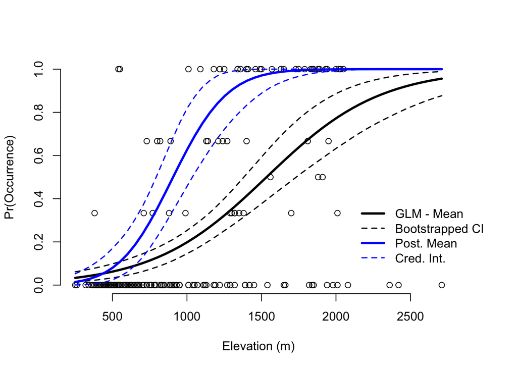

```r
#### Willow tit: GLM vs. Bayesian site-occupancy model ####

# Summarize the posterior distribution for probability of occurrence
elev.df[,c("post.mean","lwr.ci","upr.ci")] =
  t(apply(as.matrix(psi.post),2,function(x)c(mean(x),quantile(x,c(0.025,0.975)))))

# Plot fitted Pr(Occurrence) vs. elevation for GLM and Bayesian model
par(mar=c(5,4,4,4)+0.1,xpd=T)
plot(wt$elev,wt$prop,xlab="Elevation (m)",ylab="Pr(Occurrence)",axes=F)
axis(1); axis(2)
lines(elev.df$elev,elev.df$pred.mean,lwd=3)
lines(elev.df$elev,elev.df$lwr2,lty="dashed",lwd=1.6)
lines(elev.df$elev,elev.df$upr2,lty="dashed",lwd=1.6)
lines(elev.df$elev,elev.df$post.mean,col="blue",lwd=3)
lines(elev.df$elev,elev.df$lwr.ci,col="blue",lwd=1.6,lty="dashed")
lines(elev.df$elev,elev.df$upr.ci,col="blue",lwd=1.6,lty="dashed")
legend(2100,0.4,inset=c(-0.3,0),legend=c("GLM - Mean","Bootstrapped CI","Post. Mean","Cred. Int."),
       lty=c("solid","dashed","solid","dashed"),col=c("black","black","blue","blue"),
       lwd=c(3,1.6,3,1.6),bty="n")
```

#### Cross-validation

The gold standard for predictive model selection (i.e., when the goal is prediction, not inference about model parameters) is to compare the performance of competing models applied to a holdout dataset using a local and proper scoring rule (Hooten and Hobbs 2015a). That is, to use proper out-of-sample validation. Often in ecology, we do not have sufficient replication in our datasets to form separate fit and holdout sets. Cross-validation, in which $K$ subsets of the data are held out sequentially and used to assess model performance, is a powerful tool in such situations as it represents a compromise between out-of-sample prediction and in-sample fit.

The downside of cross-validation is it is computationally expensive—we need to fit our model and predict to a holdout set $K$ times! The good news is, we can use the tools from this workshop to parallelize the cross-validation procedure, thereby greatly improving its speed and making it a tractable option for model selection. Let’s demonstrate parallel cross-validation using the Bayesian site-occupancy model applied to the willow tit data. We will compare four models:

$$\begin{align}
\text{M1}&: \text{E}[v_{i}\lvert\boldsymbol{\beta}] = \beta_{0}\\[4pt]
\text{M2}&: \text{E}[v_{i}\lvert\boldsymbol{\beta}] = \beta_{0} + \beta_{1}\text{elev}_{i}\\[4pt]
\text{M3}&: \text{E}[v_{i}\lvert\boldsymbol{\beta}] = \beta_{0} + \beta_{1}\text{forest}_{i}\\[4pt]
\text{M4}&: \text{E}[v_{i}\lvert\boldsymbol{\beta}] = \beta_{0} + \beta_{1}\text{elev}_{i} + \beta_{2}\text{forest}_{i}\\[4pt]
\end{align}$$
using 10-fold cross-validation. We will use the log-predictive density (LPD; a local and proper scoring rule), which measures the probability of observing hold out data conditional on the model integrating over the uncertainty in model parameters,

$$\text{log}[\mathbf{y}_{\text{oos}}\lvert\mathbf{y}] = \text{log}\int[\mathbf{y}_{\text{oos}}\lvert\mathbf{y},\boldsymbol{\theta}][\boldsymbol{\theta}\lvert\mathbf{y}]d\boldsymbol{\theta}$$
where “oos” indicates out-of-sample observations and $\boldsymbol{\theta}$ is the set of all model parameters. More details can be found in Hooten and Hobbs (2015a).

```r
#### Willow tit: Cross-validation ####

# Add columns to wt data.frame for centered/scaled forest cover and intercept
wt$for.std = as.numeric(scale(wt$forest))
wt$intercept = 1

# Cross-validation parameters
K=10
fold.idx.mat=matrix(1:n,,K)
fold.idx.mat
```

```
##       [,1] [,2] [,3] [,4] [,5] [,6] [,7] [,8] [,9] [,10]
##  [1,]    1   21   41   61   81  101  121  141  161   181
##  [2,]    2   22   42   62   82  102  122  142  162   182
##  [3,]    3   23   43   63   83  103  123  143  163   183
##  [4,]    4   24   44   64   84  104  124  144  164   184
##  [5,]    5   25   45   65   85  105  125  145  165   185
##  [6,]    6   26   46   66   86  106  126  146  166   186
##  [7,]    7   27   47   67   87  107  127  147  167   187
##  [8,]    8   28   48   68   88  108  128  148  168   188
##  [9,]    9   29   49   69   89  109  129  149  169   189
## [10,]   10   30   50   70   90  110  130  150  170   190
## [11,]   11   31   51   71   91  111  131  151  171   191
## [12,]   12   32   52   72   92  112  132  152  172   192
## [13,]   13   33   53   73   93  113  133  153  173   193
## [14,]   14   34   54   74   94  114  134  154  174   194
## [15,]   15   35   55   75   95  115  135  155  175   195
## [16,]   16   36   56   76   96  116  136  156  176   196
## [17,]   17   37   57   77   97  117  137  157  177   197
## [18,]   18   38   58   78   98  118  138  158  178   198
## [19,]   19   39   59   79   99  119  139  159  179   199
## [20,]   20   40   60   80  100  120  140  160  180   200
```

```r
# Define function to fit each candidate model and calculate the LPD for each fold
cv.fcn <- function(k){
  score.vec=rep(0,4)
  fold.idx=fold.idx.mat[,k]
  y.oos=apply(wt[fold.idx,resp],1,sum,na.rm=T)
  cat("\n","CV-Set:",k,"|","Model: 1/4","\n")
  tmp.out.1=OccModMCMC(Y=wt[-fold.idx,resp],J=wt[-fold.idx,"visits"],X=wt[-fold.idx,"intercept"],
                       y.oos=y.oos,J.oos=wt[fold.idx,"visits"],X.oos=wt[fold.idx,"intercept"],
                       n.mcmc=n.mcmc,null.model=T)
  score.vec[1]=tmp.out.1$score
  cat("\n","CV-Set:",k,"|","Model 2/4","\n")
  tmp.out.2=OccModMCMC(Y=wt[-fold.idx,resp],J=wt[-fold.idx,"visits"],X=wt[-fold.idx,"elev.std"],
                       y.oos=y.oos,J.oos=wt[fold.idx,"visits"],X.oos=wt[fold.idx,"elev.std"],
                       n.mcmc=n.mcmc)
  score.vec[2]=tmp.out.2$score
  cat("\n","CV-Set:",k,"|","Model 3/4","\n")
  tmp.out.3=OccModMCMC(Y=wt[-fold.idx,resp],J=wt[-fold.idx,"visits"],X=wt[-fold.idx,"for.std"],
                       y.oos=y.oos,J.oos=wt[fold.idx,"visits"],X.oos=wt[fold.idx,"for.std"],
                       n.mcmc=n.mcmc)
  score.vec[3]=tmp.out.3$score
  cat("\n","CV-Set:",k,"|","Model 4/4","\n")
  tmp.out.4=OccModMCMC(Y=wt[-fold.idx,resp],J=wt[-fold.idx,"visits"],
                       X=wt[-fold.idx,c("elev.std","for.std")],
                       y.oos=y.oos,J.oos=wt[fold.idx,"visits"],
                       X.oos=wt[fold.idx,c("elev.std","for.std")],
                       n.mcmc=n.mcmc)
  score.vec[4]=tmp.out.4$score
  score.vec
}

# Define MCMC parameters
n.mcmc=50000

# Run CV in parallel
sfInit(parallel=T,cpus=my.cores,slaveOutfile="track-cv.txt")
sfExport("fold.idx.mat","wt","resp","n.mcmc","OccModMCMC")
sfClusterSetupRNG()
```

```
## [1] "RNGstream"
```

```r
cv.score.list = sfClusterApplyLB(1:K,cv.fcn)
sfStop()

# Check structure of cv.score.list
str(cv.score.list)
```

```
## List of 10
##  $ : num [1:4] -19.5 -17.2 -17 -17.1
##  $ : num [1:4] -34.5 -30.7 -31.5 -30
##  $ : num [1:4] -34.8 -32 -33.1 -31.6
##  $ : num [1:4] -27.8 -23.9 -26.1 -24.7
##  $ : num [1:4] -27.6 -24 -25.5 -23.5
##  $ : num [1:4] -35.9 -30.7 -32.9 -30.2
##  $ : num [1:4] -22.8 -15.5 -21.9 -15.8
##  $ : num [1:4] -16.2 -14.4 -18 -15.4
##  $ : num [1:4] -31.6 -28.8 -32.1 -29.1
##  $ : num [1:4] -25.5 -22 -25.2 -21.9
```

```r
# Calculate log-predictive density score for all models
lpd.scores = apply(do.call("rbind",cv.score.list),2,sum)

cat("LPD scores",
    "\n",paste(paste("M",1:4,sep=""),": ",round(lpd.scores,2),"\n",sep=""),
    "Winning model","=",paste("M",which(lpd.scores==max(lpd.scores)),sep=""))
```

```
## LPD scores
##  M1: -276.21
##  M2: -239.19
##  M3: -263.4
##  M4: -239.38
##  Winning model = M2
```

## References

Dorazio, Robert M, and Daniel Taylor Rodriguez. 2012. “A Gibbs sampler for Bayesian analysis of site-occupancy data.” *Methods in Ecology and Evolution* 3 (6): 1093–8. doi:10.1111/j.2041-210X.2012.00237.x.

Hooten, M. B., and N. T. Hobbs. 2015a. “A guide to Bayesian model selection for ecologists.” *Ecological Monographs* 85 (1): 3–28. doi:10.1890/14-0661.1.

———. 2015b. “Data and code for implementing model selection approaches for occupancy model.” *Ecological Archives*, no. M085-001-S1. doi:10.1890/14-0661.1.

Royle, J Andrew, and Robert M Dorazio. 2008. *Hierarchical Modeling and Inference in Ecology: The Analysis of Data from Populations, Metapopulations and Communities*. Elsevier.